## [Home](http://datascience-enthusiast.com/)

Simpson’s paradox is a phenomenon in probability and statistics, in which a trend appears in several different groups of data but disappears or reverses when these groups are combined ([Wikipedia](https://en.wikipedia.org/wiki/Simpson%27s_paradox)).

Let’s exlore it using the iris data. The data set consists of 50 samples from each of three species of Iris (Iris setosa, Iris virginica and Iris versicolor). Each sample has four features: the length and the width of the sepals and petals, in centimeters. You can get the data, including details, from [UCI Machine Learning Repository](http://archive.ics.uci.edu/ml/datasets/Iris)

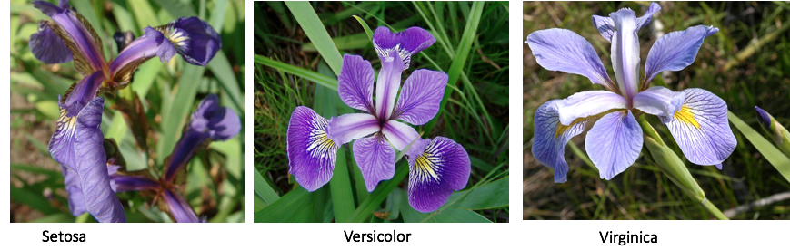

### Raw Data

```r
datatable(iris)
```

|  | Sepal.Length | Sepal.Width | Petal.Length | Petal.Width | Species |
| --- | --- | --- | --- | --- | --- |
| 1 | 5.1 | 3.5 | 1.4 | 0.2 | setosa |
| 2 | 4.9 | 3 | 1.4 | 0.2 | setosa |
| 3 | 4.7 | 3.2 | 1.3 | 0.2 | setosa |
| 4 | 4.6 | 3.1 | 1.5 | 0.2 | setosa |
| 5 | 5 | 3.6 | 1.4 | 0.2 | setosa |
| 6 | 5.4 | 3.9 | 1.7 | 0.4 | setosa |
| 7 | 4.6 | 3.4 | 1.4 | 0.3 | setosa |
| 8 | 5 | 3.4 | 1.5 | 0.2 | setosa |
| 9 | 4.4 | 2.9 | 1.4 | 0.2 | setosa |
| 10 | 4.9 | 3.1 | 1.5 | 0.1 | setosa |

[output cut: 140 more lines]

### Correlations when considering all the species together

Let’s perform correlation analysis and see if there is Simpson’s paradox in the data.

```r
cor(iris[-5])
```

```
             Sepal.Length Sepal.Width Petal.Length Petal.Width
Sepal.Length    1.0000000  -0.1175698    0.8717538   0.8179411
Sepal.Width    -0.1175698   1.0000000   -0.4284401  -0.3661259
Petal.Length    0.8717538  -0.4284401    1.0000000   0.9628654
Petal.Width     0.8179411  -0.3661259    0.9628654   1.0000000
```

#### Can the sign of the correlations change when we do the analysis for each species separately?

### Correlations by Species

```r
species_all = unique(iris$Species)
for(species in species_all){
  df = iris %>% filter(Species == species)
  message(species)
  print(cor(df[-5]))

}
```

```
setosa
```

```
             Sepal.Length Sepal.Width Petal.Length Petal.Width
Sepal.Length    1.0000000   0.7425467    0.2671758   0.2780984
Sepal.Width     0.7425467   1.0000000    0.1777000   0.2327520
Petal.Length    0.2671758   0.1777000    1.0000000   0.3316300
Petal.Width     0.2780984   0.2327520    0.3316300   1.0000000
```

```
versicolor
```

```
             Sepal.Length Sepal.Width Petal.Length Petal.Width
Sepal.Length    1.0000000   0.5259107    0.7540490   0.5464611
Sepal.Width     0.5259107   1.0000000    0.5605221   0.6639987
Petal.Length    0.7540490   0.5605221    1.0000000   0.7866681
Petal.Width     0.5464611   0.6639987    0.7866681   1.0000000
```

```
virginica
```

```
             Sepal.Length Sepal.Width Petal.Length Petal.Width
Sepal.Length    1.0000000   0.4572278    0.8642247   0.2811077
Sepal.Width     0.4572278   1.0000000    0.4010446   0.5377280
Petal.Length    0.8642247   0.4010446    1.0000000   0.3221082
Petal.Width     0.2811077   0.5377280    0.3221082   1.0000000
```

**We see that some correlations have changed from negetaive to positive. Let’s explore what could be resulting in such pattern**.

### Exploration

Let’s explore what is happening by taking Petal.Length and Sepal.Width

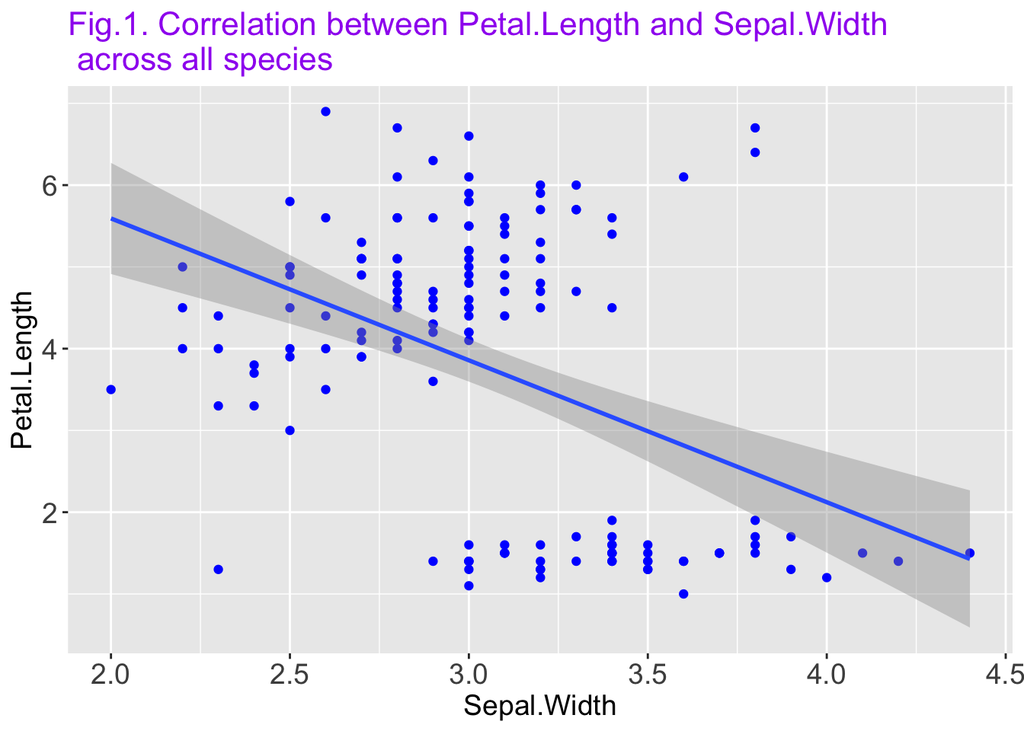

```r
iris %>% ggplot(aes(x = Sepal.Width , y = Petal.Length)) + geom_point(color = 'blue') + ggtitle('Fig.1. Correlation between Petal.Length and Sepal.Width \n across all species') + theme(axis.title = element_text(size=14), plot.title = element_text(size = 16,colour="purple"),
axis.text = element_text(size=14)) + geom_smooth(method = "lm")
```

From the above figure, we observe that there are two pockets of data which are resulting in the negative correlations.

#### Correlations at Species level

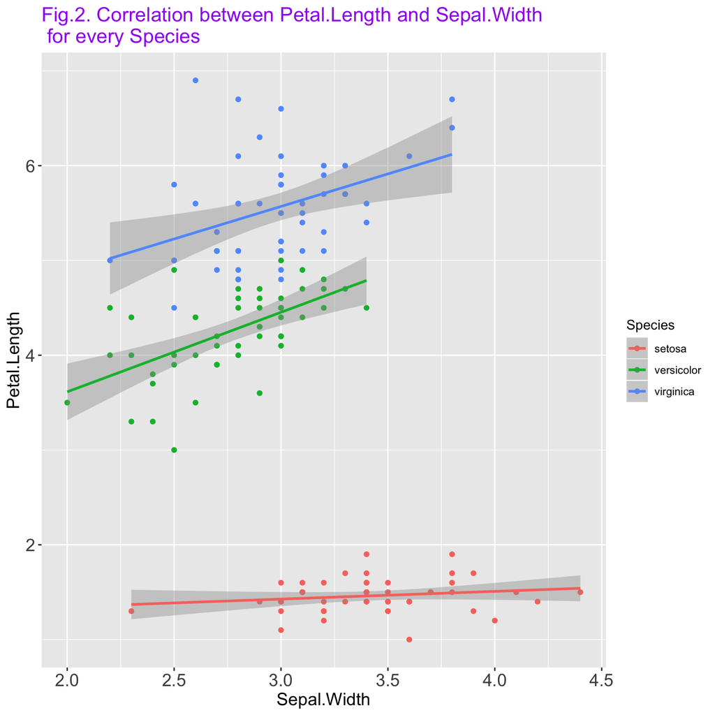

```r
iris %>% ggplot(aes(x = Sepal.Width , y = Petal.Length, color = Species)) + geom_point() + ggtitle('Fig.2. Correlation between Petal.Length and Sepal.Width \n for every Species')  + geom_smooth(method = 'lm') + theme(axis.title = element_text(size=14), plot.title = element_text(size = 16,colour="purple"), axis.text = element_text(size=14))
```

When we do the analysis at Species level, we see strong positive correlations for versicolor and virginica and weak correlation for setosa. Versicolor and Virginica are the upper left cluster in Fig.1 above and setosa is the bottom right cluster.

### What happens if we consider versicolor and virginica together?

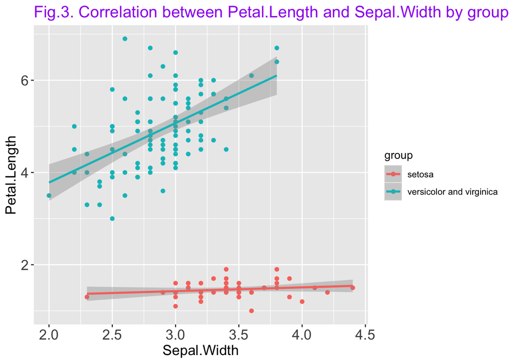

```r
iris %>% mutate(group = ifelse(Species %in% c("versicolor", 'virginica'), 'versicolor and virginica','setosa')) %>% ggplot(aes(x = Sepal.Width , y = Petal.Length, color = group)) + geom_point() + ggtitle('Fig.3. Correlation between Petal.Length and Sepal.Width by group') + theme(axis.title = element_text(size=14), plot.title = element_text(size = 16,colour="purple"),
axis.text = element_text(size=14)) + geom_smooth(method = "lm")
```

So when we do the correlations for each cluster above, we observe strong positive correlation for the upper cluster (virginica and versicolor) and a weak positive correlation for the lower cluster (setosa).

### Final Remarks

When we do analysis, having a business understanding is very important, if not more, as more as the technical skills. Further, we have to slice and dice our data from different dimensions before coming to conclusions.